# Risk Factor Analysis

## Outcome Variable

**Outcome Variable:** ever_co

## Predictor Variables

**Intervention Variable:** birthwt

**Adjustment Set:**

- arm
- sex
- W_mage
- meducyrs
- feducyrs
- vagbrth
- single
- brthmon
- W_parity
- delta_W_mage
- delta_meducyrs
- delta_feducyrs
- delta_vagbrth
- delta_single
- delta_brthmon
- delta_W_parity

## Stratifying Variables

The analysis was stratified on these variable(s):

- agecat
- studyid
- country

## Data Summary

| agecat | studyid | country | birthwt | ever_co | n_cell | n |
| --- | --- | --- | --- | --- | --- | --- |
| 0-24 months | ki0047075b-MAL-ED | BANGLADESH | Normal or high birthweight | 0 | 183 | 257 |
| 0-24 months | ki0047075b-MAL-ED | BANGLADESH | Normal or high birthweight | 1 | 21 | 257 |
| 0-24 months | ki0047075b-MAL-ED | BANGLADESH | Low birth weight | 0 | 37 | 257 |
| 0-24 months | ki0047075b-MAL-ED | BANGLADESH | Low birth weight | 1 | 16 | 257 |
| 0-24 months | ki0047075b-MAL-ED | BRAZIL | Normal or high birthweight | 0 | 219 | 233 |
| 0-24 months | ki0047075b-MAL-ED | BRAZIL | Normal or high birthweight | 1 | 2 | 233 |
| 0-24 months | ki0047075b-MAL-ED | BRAZIL | Low birth weight | 0 | 12 | 233 |
| 0-24 months | ki0047075b-MAL-ED | BRAZIL | Low birth weight | 1 | 0 | 233 |
| 0-24 months | ki0047075b-MAL-ED | INDIA | Normal or high birthweight | 0 | 168 | 243 |
| 0-24 months | ki0047075b-MAL-ED | INDIA | Normal or high birthweight | 1 | 37 | 243 |
| 0-24 months | ki0047075b-MAL-ED | INDIA | Low birth weight | 0 | 24 | 243 |
| 0-24 months | ki0047075b-MAL-ED | INDIA | Low birth weight | 1 | 14 | 243 |
| 0-24 months | ki0047075b-MAL-ED | NEPAL | Normal or high birthweight | 0 | 200 | 233 |
| 0-24 months | ki0047075b-MAL-ED | NEPAL | Normal or high birthweight | 1 | 12 | 233 |
| 0-24 months | ki0047075b-MAL-ED | NEPAL | Low birth weight | 0 | 15 | 233 |
| 0-24 months | ki0047075b-MAL-ED | NEPAL | Low birth weight | 1 | 6 | 233 |
| 0-24 months | ki0047075b-MAL-ED | PERU | Normal or high birthweight | 0 | 274 | 299 |
| 0-24 months | ki0047075b-MAL-ED | PERU | Normal or high birthweight | 1 | 7 | 299 |
| 0-24 months | ki0047075b-MAL-ED | PERU | Low birth weight | 0 | 13 | 299 |
| 0-24 months | ki0047075b-MAL-ED | PERU | Low birth weight | 1 | 5 | 299 |
| 0-24 months | ki0047075b-MAL-ED | SOUTH AFRICA | Normal or high birthweight | 0 | 275 | 312 |
| 0-24 months | ki0047075b-MAL-ED | SOUTH AFRICA | Normal or high birthweight | 1 | 15 | 312 |
| 0-24 months | ki0047075b-MAL-ED | SOUTH AFRICA | Low birth weight | 0 | 15 | 312 |
| 0-24 months | ki0047075b-MAL-ED | SOUTH AFRICA | Low birth weight | 1 | 7 | 312 |
| 0-24 months | ki0047075b-MAL-ED | TANZANIA, UNITED REPUBLIC OF | Normal or high birthweight | 0 | 120 | 135 |
| 0-24 months | ki0047075b-MAL-ED | TANZANIA, UNITED REPUBLIC OF | Normal or high birthweight | 1 | 8 | 135 |
| 0-24 months | ki0047075b-MAL-ED | TANZANIA, UNITED REPUBLIC OF | Low birth weight | 0 | 6 | 135 |
| 0-24 months | ki0047075b-MAL-ED | TANZANIA, UNITED REPUBLIC OF | Low birth weight | 1 | 1 | 135 |
| 0-24 months | ki1000108-CMC-V-BCS-2002 | INDIA | Normal or high birthweight | 0 | 271 | 373 |
| 0-24 months | ki1000108-CMC-V-BCS-2002 | INDIA | Normal or high birthweight | 1 | 59 | 373 |

[output cut: 318 more lines]

The following strata were considered:

- agecat: 0-24 months, studyid: ki0047075b-MAL-ED, country: BANGLADESH
- agecat: 0-24 months, studyid: ki0047075b-MAL-ED, country: BRAZIL
- agecat: 0-24 months, studyid: ki0047075b-MAL-ED, country: INDIA
- agecat: 0-24 months, studyid: ki0047075b-MAL-ED, country: NEPAL
- agecat: 0-24 months, studyid: ki0047075b-MAL-ED, country: PERU
- agecat: 0-24 months, studyid: ki0047075b-MAL-ED, country: SOUTH AFRICA
- agecat: 0-24 months, studyid: ki0047075b-MAL-ED, country: TANZANIA, UNITED REPUBLIC OF
- agecat: 0-24 months, studyid: ki1000108-CMC-V-BCS-2002, country: INDIA
- agecat: 0-24 months, studyid: ki1000108-IRC, country: INDIA
- agecat: 0-24 months, studyid: ki1000109-EE, country: PAKISTAN
- agecat: 0-24 months, studyid: ki1000109-ResPak, country: PAKISTAN
- agecat: 0-24 months, studyid: ki1000304b-SAS-CompFeed, country: INDIA
- agecat: 0-24 months, studyid: ki1017093-NIH-Birth, country: BANGLADESH
- agecat: 0-24 months, studyid: ki1017093b-PROVIDE, country: BANGLADESH
- agecat: 0-24 months, studyid: ki1017093c-NIH-Crypto, country: BANGLADESH
- agecat: 0-24 months, studyid: ki1066203-TanzaniaChild2, country: TANZANIA, UNITED REPUBLIC OF
- agecat: 0-24 months, studyid: ki1101329-Keneba, country: GAMBIA
- agecat: 0-24 months, studyid: ki1114097-CMIN, country: BANGLADESH
- agecat: 0-24 months, studyid: ki1114097-CMIN, country: BRAZIL
- agecat: 0-24 months, studyid: ki1114097-CMIN, country: GUINEA-BISSAU
- agecat: 0-24 months, studyid: ki1114097-CMIN, country: PERU
- agecat: 0-24 months, studyid: ki1114097-CONTENT, country: PERU
- agecat: 0-24 months, studyid: ki1119695-PROBIT, country: BELARUS
- agecat: 0-24 months, studyid: ki1126311-ZVITAMBO, country: ZIMBABWE
- agecat: 0-24 months, studyid: ki1135781-COHORTS, country: GUATEMALA
- agecat: 0-24 months, studyid: ki1135781-COHORTS, country: INDIA
- agecat: 0-24 months, studyid: ki1135781-COHORTS, country: PHILIPPINES
- agecat: 0-24 months, studyid: kiGH5241-JiVitA-3, country: BANGLADESH
- agecat: 0-24 months, studyid: kiGH5241-JiVitA-4, country: BANGLADESH
- agecat: 0-6 months, studyid: ki0047075b-MAL-ED, country: BANGLADESH
- agecat: 0-6 months, studyid: ki0047075b-MAL-ED, country: BRAZIL
- agecat: 0-6 months, studyid: ki0047075b-MAL-ED, country: INDIA
- agecat: 0-6 months, studyid: ki0047075b-MAL-ED, country: NEPAL
- agecat: 0-6 months, studyid: ki0047075b-MAL-ED, country: PERU
- agecat: 0-6 months, studyid: ki0047075b-MAL-ED, country: SOUTH AFRICA
- agecat: 0-6 months, studyid: ki0047075b-MAL-ED, country: TANZANIA, UNITED REPUBLIC OF
- agecat: 0-6 months, studyid: ki1000108-CMC-V-BCS-2002, country: INDIA
- agecat: 0-6 months, studyid: ki1000108-IRC, country: INDIA
- agecat: 0-6 months, studyid: ki1000109-EE, country: PAKISTAN
- agecat: 0-6 months, studyid: ki1000109-ResPak, country: PAKISTAN
- agecat: 0-6 months, studyid: ki1000304b-SAS-CompFeed, country: INDIA
- agecat: 0-6 months, studyid: ki1017093-NIH-Birth, country: BANGLADESH
- agecat: 0-6 months, studyid: ki1017093b-PROVIDE, country: BANGLADESH
- agecat: 0-6 months, studyid: ki1017093c-NIH-Crypto, country: BANGLADESH
- agecat: 0-6 months, studyid: ki1066203-TanzaniaChild2, country: TANZANIA, UNITED REPUBLIC OF
- agecat: 0-6 months, studyid: ki1101329-Keneba, country: GAMBIA
- agecat: 0-6 months, studyid: ki1114097-CMIN, country: BANGLADESH
- agecat: 0-6 months, studyid: ki1114097-CMIN, country: BRAZIL
- agecat: 0-6 months, studyid: ki1114097-CMIN, country: GUINEA-BISSAU
- agecat: 0-6 months, studyid: ki1114097-CMIN, country: PERU
- agecat: 0-6 months, studyid: ki1114097-CONTENT, country: PERU
- agecat: 0-6 months, studyid: ki1119695-PROBIT, country: BELARUS
- agecat: 0-6 months, studyid: ki1126311-ZVITAMBO, country: ZIMBABWE
- agecat: 0-6 months, studyid: ki1135781-COHORTS, country: GUATEMALA
- agecat: 0-6 months, studyid: ki1135781-COHORTS, country: INDIA
- agecat: 0-6 months, studyid: ki1135781-COHORTS, country: PHILIPPINES
- agecat: 0-6 months, studyid: kiGH5241-JiVitA-3, country: BANGLADESH
- agecat: 0-6 months, studyid: kiGH5241-JiVitA-4, country: BANGLADESH
- agecat: 6-24 months, studyid: ki0047075b-MAL-ED, country: BANGLADESH
- agecat: 6-24 months, studyid: ki0047075b-MAL-ED, country: BRAZIL
- agecat: 6-24 months, studyid: ki0047075b-MAL-ED, country: INDIA
- agecat: 6-24 months, studyid: ki0047075b-MAL-ED, country: NEPAL
- agecat: 6-24 months, studyid: ki0047075b-MAL-ED, country: PERU
- agecat: 6-24 months, studyid: ki0047075b-MAL-ED, country: SOUTH AFRICA
- agecat: 6-24 months, studyid: ki0047075b-MAL-ED, country: TANZANIA, UNITED REPUBLIC OF
- agecat: 6-24 months, studyid: ki1000108-CMC-V-BCS-2002, country: INDIA
- agecat: 6-24 months, studyid: ki1000108-IRC, country: INDIA
- agecat: 6-24 months, studyid: ki1000109-EE, country: PAKISTAN
- agecat: 6-24 months, studyid: ki1000109-ResPak, country: PAKISTAN
- agecat: 6-24 months, studyid: ki1000304b-SAS-CompFeed, country: INDIA
- agecat: 6-24 months, studyid: ki1017093-NIH-Birth, country: BANGLADESH
- agecat: 6-24 months, studyid: ki1017093b-PROVIDE, country: BANGLADESH
- agecat: 6-24 months, studyid: ki1017093c-NIH-Crypto, country: BANGLADESH
- agecat: 6-24 months, studyid: ki1066203-TanzaniaChild2, country: TANZANIA, UNITED REPUBLIC OF
- agecat: 6-24 months, studyid: ki1101329-Keneba, country: GAMBIA
- agecat: 6-24 months, studyid: ki1114097-CMIN, country: BANGLADESH
- agecat: 6-24 months, studyid: ki1114097-CMIN, country: BRAZIL
- agecat: 6-24 months, studyid: ki1114097-CMIN, country: GUINEA-BISSAU
- agecat: 6-24 months, studyid: ki1114097-CMIN, country: PERU
- agecat: 6-24 months, studyid: ki1114097-CONTENT, country: PERU
- agecat: 6-24 months, studyid: ki1119695-PROBIT, country: BELARUS
- agecat: 6-24 months, studyid: ki1126311-ZVITAMBO, country: ZIMBABWE
- agecat: 6-24 months, studyid: ki1135781-COHORTS, country: GUATEMALA
- agecat: 6-24 months, studyid: ki1135781-COHORTS, country: INDIA
- agecat: 6-24 months, studyid: ki1135781-COHORTS, country: PHILIPPINES
- agecat: 6-24 months, studyid: kiGH5241-JiVitA-3, country: BANGLADESH
- agecat: 6-24 months, studyid: kiGH5241-JiVitA-4, country: BANGLADESH

### Dropped Strata

Some strata were dropped due to rare outcomes:

- agecat: 0-24 months, studyid: ki0047075b-MAL-ED, country: BRAZIL
- agecat: 0-24 months, studyid: ki0047075b-MAL-ED, country: TANZANIA, UNITED REPUBLIC OF
- agecat: 0-24 months, studyid: ki1000109-ResPak, country: PAKISTAN
- agecat: 0-24 months, studyid: ki1114097-CMIN, country: BANGLADESH
- agecat: 0-24 months, studyid: ki1114097-CMIN, country: BRAZIL
- agecat: 0-24 months, studyid: ki1114097-CMIN, country: GUINEA-BISSAU
- agecat: 0-24 months, studyid: ki1114097-CMIN, country: PERU
- agecat: 0-24 months, studyid: ki1114097-CONTENT, country: PERU
- agecat: 0-24 months, studyid: ki1119695-PROBIT, country: BELARUS
- agecat: 0-6 months, studyid: ki0047075b-MAL-ED, country: BANGLADESH
- agecat: 0-6 months, studyid: ki0047075b-MAL-ED, country: BRAZIL
- agecat: 0-6 months, studyid: ki0047075b-MAL-ED, country: INDIA
- agecat: 0-6 months, studyid: ki0047075b-MAL-ED, country: NEPAL
- agecat: 0-6 months, studyid: ki0047075b-MAL-ED, country: PERU
- agecat: 0-6 months, studyid: ki0047075b-MAL-ED, country: SOUTH AFRICA
- agecat: 0-6 months, studyid: ki0047075b-MAL-ED, country: TANZANIA, UNITED REPUBLIC OF
- agecat: 0-6 months, studyid: ki1000109-ResPak, country: PAKISTAN
- agecat: 0-6 months, studyid: ki1017093-NIH-Birth, country: BANGLADESH
- agecat: 0-6 months, studyid: ki1017093c-NIH-Crypto, country: BANGLADESH
- agecat: 0-6 months, studyid: ki1114097-CMIN, country: BANGLADESH
- agecat: 0-6 months, studyid: ki1114097-CMIN, country: BRAZIL
- agecat: 0-6 months, studyid: ki1114097-CMIN, country: GUINEA-BISSAU
- agecat: 0-6 months, studyid: ki1114097-CMIN, country: PERU
- agecat: 0-6 months, studyid: ki1114097-CONTENT, country: PERU
- agecat: 0-6 months, studyid: ki1119695-PROBIT, country: BELARUS
- agecat: 0-6 months, studyid: ki1135781-COHORTS, country: GUATEMALA
- agecat: 6-24 months, studyid: ki0047075b-MAL-ED, country: BRAZIL
- agecat: 6-24 months, studyid: ki0047075b-MAL-ED, country: NEPAL
- agecat: 6-24 months, studyid: ki0047075b-MAL-ED, country: PERU
- agecat: 6-24 months, studyid: ki0047075b-MAL-ED, country: SOUTH AFRICA
- agecat: 6-24 months, studyid: ki0047075b-MAL-ED, country: TANZANIA, UNITED REPUBLIC OF
- agecat: 6-24 months, studyid: ki1000109-ResPak, country: PAKISTAN
- agecat: 6-24 months, studyid: ki1114097-CMIN, country: BANGLADESH
- agecat: 6-24 months, studyid: ki1114097-CMIN, country: BRAZIL
- agecat: 6-24 months, studyid: ki1114097-CMIN, country: GUINEA-BISSAU
- agecat: 6-24 months, studyid: ki1114097-CMIN, country: PERU
- agecat: 6-24 months, studyid: ki1114097-CONTENT, country: PERU
- agecat: 6-24 months, studyid: ki1119695-PROBIT, country: BELARUS

## Methods Detail

We’re interested in the causal parameters $E[Y_a]$ for all values of $a \in \mathcal{A}$. These parameters represent the mean outcome if, possibly contrary to fact, we intervened to set all units to have $A=a$. Under the randomization and positivity assumptions, these are identified by the statistical parameters $\psi_a=E_W[E_{Y|A,W}(Y|A=a,W)]$. In addition, we’re interested in the mean of $Y$, $E[Y]$ under no intervention (the observed mean). We will estimate these parameters by using SuperLearner to fit the relevant likelihood factors – $E_{Y|A,W}(Y|A=a,W)$ and $p(A=a|W)$, and then updating our likelihood fit using a joint TMLE.

For unadjusted analyses ($W=\{\}$), initial likelihoods were estimated using Lrnr_glm to estimate the simple $E(Y|A)$ and Lrnr_mean to estimate $p(A)$. For adjusted analyses, a small library containing Lrnr_glmnet, Lrnr_xgboost, and Lrnr_mean was used.

Having estimated these parameters, we will then use the delta method to estimate relative risks and attributable risks relative to a prespecified baseline level of $A$.

# Results Detail

## Results Plots

[figure not shown]

[figure not shown]

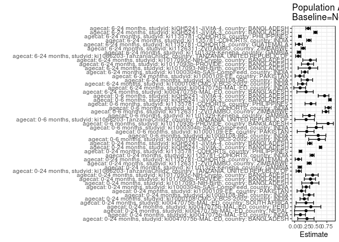

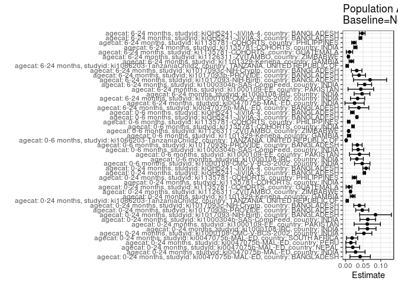

## Results Table

### Parameter: TSM

| agecat | studyid | country | intervention_level | baseline_level | estimate | ci_lower | ci_upper |
| --- | --- | --- | --- | --- | --- | --- | --- |
| 0-24 months | ki0047075b-MAL-ED | BANGLADESH | Normal or high birthweight | NA | 0.1023626 | 0.0604733 | 0.1442520 |
| 0-24 months | ki0047075b-MAL-ED | BANGLADESH | Low birth weight | NA | 0.2801223 | 0.1564591 | 0.4037854 |
| 0-24 months | ki0047075b-MAL-ED | INDIA | Normal or high birthweight | NA | 0.1812885 | 0.1284321 | 0.2341449 |
| 0-24 months | ki0047075b-MAL-ED | INDIA | Low birth weight | NA | 0.3345160 | 0.1722087 | 0.4968232 |
| 0-24 months | ki0047075b-MAL-ED | NEPAL | Normal or high birthweight | NA | 0.0566038 | 0.0254304 | 0.0877772 |
| 0-24 months | ki0047075b-MAL-ED | NEPAL | Low birth weight | NA | 0.2857143 | 0.0920835 | 0.4793451 |
| 0-24 months | ki0047075b-MAL-ED | PERU | Normal or high birthweight | NA | 0.0249110 | 0.0066578 | 0.0431643 |
| 0-24 months | ki0047075b-MAL-ED | PERU | Low birth weight | NA | 0.2777778 | 0.0705140 | 0.4850416 |
| 0-24 months | ki0047075b-MAL-ED | SOUTH AFRICA | Normal or high birthweight | NA | 0.0517241 | 0.0261936 | 0.0772547 |
| 0-24 months | ki0047075b-MAL-ED | SOUTH AFRICA | Low birth weight | NA | 0.3181818 | 0.1232396 | 0.5131240 |
| 0-24 months | ki1000108-CMC-V-BCS-2002 | INDIA | Normal or high birthweight | NA | 0.1783995 | 0.1369634 | 0.2198357 |
| 0-24 months | ki1000108-CMC-V-BCS-2002 | INDIA | Low birth weight | NA | 0.6029840 | 0.4520334 | 0.7539346 |
| 0-24 months | ki1000108-IRC | INDIA | Normal or high birthweight | NA | 0.1215964 | 0.0864868 | 0.1567059 |
| 0-24 months | ki1000108-IRC | INDIA | Low birth weight | NA | 0.4987241 | 0.3802613 | 0.6171868 |
| 0-24 months | ki1000109-EE | PAKISTAN | Normal or high birthweight | NA | 0.3181044 | 0.2591800 | 0.3770288 |
| 0-24 months | ki1000109-EE | PAKISTAN | Low birth weight | NA | 0.4938401 | 0.4109745 | 0.5767057 |
| 0-24 months | ki1000304b-SAS-CompFeed | INDIA | Normal or high birthweight | NA | 0.1696981 | 0.1335411 | 0.2058550 |
| 0-24 months | ki1000304b-SAS-CompFeed | INDIA | Low birth weight | NA | 0.4317806 | 0.3674003 | 0.4961609 |
| 0-24 months | ki1017093-NIH-Birth | BANGLADESH | Normal or high birthweight | NA | 0.1281023 | 0.0728926 | 0.1833121 |
| 0-24 months | ki1017093-NIH-Birth | BANGLADESH | Low birth weight | NA | 0.3664738 | 0.2591089 | 0.4738388 |
| 0-24 months | ki1017093b-PROVIDE | BANGLADESH | Normal or high birthweight | NA | 0.0810096 | 0.0575824 | 0.1044368 |
| 0-24 months | ki1017093b-PROVIDE | BANGLADESH | Low birth weight | NA | 0.2983635 | 0.2277807 | 0.3689463 |
| 0-24 months | ki1017093c-NIH-Crypto | BANGLADESH | Normal or high birthweight | NA | 0.0542104 | 0.0356698 | 0.0727509 |
| 0-24 months | ki1017093c-NIH-Crypto | BANGLADESH | Low birth weight | NA | 0.2270593 | 0.1650173 | 0.2891014 |
| 0-24 months | ki1066203-TanzaniaChild2 | TANZANIA, UNITED REPUBLIC OF | Normal or high birthweight | NA | 0.0440265 | 0.0356172 | 0.0524358 |
| 0-24 months | ki1066203-TanzaniaChild2 | TANZANIA, UNITED REPUBLIC OF | Low birth weight | NA | 0.1803634 | 0.0971763 | 0.2635505 |
| 0-24 months | ki1101329-Keneba | GAMBIA | Normal or high birthweight | NA | 0.1425036 | 0.1268469 | 0.1581603 |
| 0-24 months | ki1101329-Keneba | GAMBIA | Low birth weight | NA | 0.3637936 | 0.2982977 | 0.4292895 |
| 0-24 months | ki1126311-ZVITAMBO | ZIMBABWE | Normal or high birthweight | NA | 0.0275647 | 0.0246403 | 0.0304891 |
| 0-24 months | ki1126311-ZVITAMBO | ZIMBABWE | Low birth weight | NA | 0.1388921 | 0.1227101 | 0.1550741 |

[output cut: 68 more lines]

### Parameter: E(Y)

| agecat | studyid | country | intervention_level | baseline_level | estimate | ci_lower | ci_upper |
| --- | --- | --- | --- | --- | --- | --- | --- |
| 0-24 months | ki0047075b-MAL-ED | BANGLADESH | NA | NA | 0.1439689 | 0.1009650 | 0.1869727 |
| 0-24 months | ki0047075b-MAL-ED | INDIA | NA | NA | 0.2098765 | 0.1585703 | 0.2611827 |
| 0-24 months | ki0047075b-MAL-ED | NEPAL | NA | NA | 0.0772532 | 0.0428971 | 0.1116093 |
| 0-24 months | ki0047075b-MAL-ED | PERU | NA | NA | 0.0401338 | 0.0178494 | 0.0624181 |
| 0-24 months | ki0047075b-MAL-ED | SOUTH AFRICA | NA | NA | 0.0705128 | 0.0420601 | 0.0989655 |
| 0-24 months | ki1000108-CMC-V-BCS-2002 | INDIA | NA | NA | 0.2305630 | 0.1877616 | 0.2733644 |
| 0-24 months | ki1000108-IRC | INDIA | NA | NA | 0.1838235 | 0.1461927 | 0.2214543 |
| 0-24 months | ki1000109-EE | PAKISTAN | NA | NA | 0.3799472 | 0.3310169 | 0.4288776 |
| 0-24 months | ki1000304b-SAS-CompFeed | INDIA | NA | NA | 0.2328676 | 0.1923832 | 0.2733520 |
| 0-24 months | ki1017093-NIH-Birth | BANGLADESH | NA | NA | 0.2133333 | 0.1596859 | 0.2669808 |
| 0-24 months | ki1017093b-PROVIDE | BANGLADESH | NA | NA | 0.1285714 | 0.1037574 | 0.1533855 |
| 0-24 months | ki1017093c-NIH-Crypto | BANGLADESH | NA | NA | 0.0936675 | 0.0729118 | 0.1144233 |
| 0-24 months | ki1066203-TanzaniaChild2 | TANZANIA, UNITED REPUBLIC OF | NA | NA | 0.0489245 | 0.0402400 | 0.0576090 |
| 0-24 months | ki1101329-Keneba | GAMBIA | NA | NA | 0.1628126 | 0.1470895 | 0.1785358 |
| 0-24 months | ki1126311-ZVITAMBO | ZIMBABWE | NA | NA | 0.0418287 | 0.0384992 | 0.0451581 |
| 0-24 months | ki1135781-COHORTS | GUATEMALA | NA | NA | 0.1097955 | 0.0896809 | 0.1299101 |
| 0-24 months | ki1135781-COHORTS | INDIA | NA | NA | 0.0904114 | 0.0835737 | 0.0972490 |
| 0-24 months | ki1135781-COHORTS | PHILIPPINES | NA | NA | 0.1832722 | 0.1694278 | 0.1971167 |
| 0-24 months | kiGH5241-JiVitA-3 | BANGLADESH | NA | NA | 0.0886038 | 0.0847199 | 0.0924878 |
| 0-24 months | kiGH5241-JiVitA-4 | BANGLADESH | NA | NA | 0.1645963 | 0.1519758 | 0.1772167 |
| 0-6 months | ki1000108-CMC-V-BCS-2002 | INDIA | NA | NA | 0.0842391 | 0.0558231 | 0.1126551 |
| 0-6 months | ki1000108-IRC | INDIA | NA | NA | 0.0589681 | 0.0360543 | 0.0818818 |
| 0-6 months | ki1000109-EE | PAKISTAN | NA | NA | 0.1398417 | 0.1048786 | 0.1748048 |
| 0-6 months | ki1000304b-SAS-CompFeed | INDIA | NA | NA | 0.0709030 | 0.0481799 | 0.0936261 |
| 0-6 months | ki1017093b-PROVIDE | BANGLADESH | NA | NA | 0.0428571 | 0.0278427 | 0.0578716 |
| 0-6 months | ki1066203-TanzaniaChild2 | TANZANIA, UNITED REPUBLIC OF | NA | NA | 0.0071700 | 0.0037732 | 0.0105668 |
| 0-6 months | ki1101329-Keneba | GAMBIA | NA | NA | 0.0292909 | 0.0217971 | 0.0367846 |
| 0-6 months | ki1126311-ZVITAMBO | ZIMBABWE | NA | NA | 0.0121041 | 0.0102794 | 0.0139288 |
| 0-6 months | ki1135781-COHORTS | INDIA | NA | NA | 0.0269983 | 0.0230857 | 0.0309109 |
| 0-6 months | ki1135781-COHORTS | PHILIPPINES | NA | NA | 0.0236667 | 0.0182263 | 0.0291070 |
| 0-6 months | kiGH5241-JiVitA-3 | BANGLADESH | NA | NA | 0.0393827 | 0.0368929 | 0.0418726 |
| 0-6 months | kiGH5241-JiVitA-4 | BANGLADESH | NA | NA | 0.0277653 | 0.0218336 | 0.0336971 |
| 6-24 months | ki0047075b-MAL-ED | BANGLADESH | NA | NA | 0.1410256 | 0.0963358 | 0.1857155 |
| 6-24 months | ki0047075b-MAL-ED | INDIA | NA | NA | 0.1973684 | 0.1455920 | 0.2491449 |
| 6-24 months | ki1000108-CMC-V-BCS-2002 | INDIA | NA | NA | 0.1876676 | 0.1479906 | 0.2273445 |
| 6-24 months | ki1000108-IRC | INDIA | NA | NA | 0.1568627 | 0.1215314 | 0.1921941 |
| 6-24 months | ki1000109-EE | PAKISTAN | NA | NA | 0.3538874 | 0.3052956 | 0.4024792 |
| 6-24 months | ki1000304b-SAS-CompFeed | INDIA | NA | NA | 0.2269761 | 0.1910133 | 0.2629388 |
| 6-24 months | ki1017093-NIH-Birth | BANGLADESH | NA | NA | 0.2000000 | 0.1414022 | 0.2585978 |
| 6-24 months | ki1017093b-PROVIDE | BANGLADESH | NA | NA | 0.1221498 | 0.0962275 | 0.1480722 |
| 6-24 months | ki1017093c-NIH-Crypto | BANGLADESH | NA | NA | 0.0863014 | 0.0659171 | 0.1066856 |
| 6-24 months | ki1066203-TanzaniaChild2 | TANZANIA, UNITED REPUBLIC OF | NA | NA | 0.0555834 | 0.0455321 | 0.0656347 |
| 6-24 months | ki1101329-Keneba | GAMBIA | NA | NA | 0.1584110 | 0.1425588 | 0.1742632 |
| 6-24 months | ki1126311-ZVITAMBO | ZIMBABWE | NA | NA | 0.0407206 | 0.0369682 | 0.0444730 |
| 6-24 months | ki1135781-COHORTS | GUATEMALA | NA | NA | 0.1090909 | 0.0878048 | 0.1303770 |
| 6-24 months | ki1135781-COHORTS | INDIA | NA | NA | 0.0837039 | 0.0768626 | 0.0905453 |
| 6-24 months | ki1135781-COHORTS | PHILIPPINES | NA | NA | 0.1902351 | 0.1756031 | 0.2048671 |
| 6-24 months | kiGH5241-JiVitA-3 | BANGLADESH | NA | NA | 0.0869919 | 0.0823156 | 0.0916682 |
| 6-24 months | kiGH5241-JiVitA-4 | BANGLADESH | NA | NA | 0.1486997 | 0.1368826 | 0.1605168 |

### Parameter: RR

| agecat | studyid | country | intervention_level | baseline_level | estimate | ci_lower | ci_upper |
| --- | --- | --- | --- | --- | --- | --- | --- |
| 0-24 months | ki0047075b-MAL-ED | BANGLADESH | Normal or high birthweight | Normal or high birthweight | 1.000000 | 1.0000000 | 1.000000 |
| 0-24 months | ki0047075b-MAL-ED | BANGLADESH | Low birth weight | Normal or high birthweight | 2.736568 | 1.4935449 | 5.014113 |
| 0-24 months | ki0047075b-MAL-ED | INDIA | Normal or high birthweight | Normal or high birthweight | 1.000000 | 1.0000000 | 1.000000 |
| 0-24 months | ki0047075b-MAL-ED | INDIA | Low birth weight | Normal or high birthweight | 1.845213 | 1.0467733 | 3.252674 |
| 0-24 months | ki0047075b-MAL-ED | NEPAL | Normal or high birthweight | Normal or high birthweight | 1.000000 | 1.0000000 | 1.000000 |
| 0-24 months | ki0047075b-MAL-ED | NEPAL | Low birth weight | Normal or high birthweight | 5.047619 | 2.1078156 | 12.087613 |
| 0-24 months | ki0047075b-MAL-ED | PERU | Normal or high birthweight | Normal or high birthweight | 1.000000 | 1.0000000 | 1.000000 |
| 0-24 months | ki0047075b-MAL-ED | PERU | Low birth weight | Normal or high birthweight | 11.150794 | 3.9186069 | 31.730715 |
| 0-24 months | ki0047075b-MAL-ED | SOUTH AFRICA | Normal or high birthweight | Normal or high birthweight | 1.000000 | 1.0000000 | 1.000000 |
| 0-24 months | ki0047075b-MAL-ED | SOUTH AFRICA | Low birth weight | Normal or high birthweight | 6.151515 | 2.8008727 | 13.510481 |
| 0-24 months | ki1000108-CMC-V-BCS-2002 | INDIA | Normal or high birthweight | Normal or high birthweight | 1.000000 | 1.0000000 | 1.000000 |
| 0-24 months | ki1000108-CMC-V-BCS-2002 | INDIA | Low birth weight | Normal or high birthweight | 3.379964 | 2.4021740 | 4.755759 |
| 0-24 months | ki1000108-IRC | INDIA | Normal or high birthweight | Normal or high birthweight | 1.000000 | 1.0000000 | 1.000000 |
| 0-24 months | ki1000108-IRC | INDIA | Low birth weight | Normal or high birthweight | 4.101472 | 2.8265975 | 5.951351 |
| 0-24 months | ki1000109-EE | PAKISTAN | Normal or high birthweight | Normal or high birthweight | 1.000000 | 1.0000000 | 1.000000 |
| 0-24 months | ki1000109-EE | PAKISTAN | Low birth weight | Normal or high birthweight | 1.552447 | 1.2096698 | 1.992354 |
| 0-24 months | ki1000304b-SAS-CompFeed | INDIA | Normal or high birthweight | Normal or high birthweight | 1.000000 | 1.0000000 | 1.000000 |
| 0-24 months | ki1000304b-SAS-CompFeed | INDIA | Low birth weight | Normal or high birthweight | 2.544405 | 2.0894548 | 3.098415 |
| 0-24 months | ki1017093-NIH-Birth | BANGLADESH | Normal or high birthweight | Normal or high birthweight | 1.000000 | 1.0000000 | 1.000000 |
| 0-24 months | ki1017093-NIH-Birth | BANGLADESH | Low birth weight | Normal or high birthweight | 2.860789 | 1.6989410 | 4.817186 |
| 0-24 months | ki1017093b-PROVIDE | BANGLADESH | Normal or high birthweight | Normal or high birthweight | 1.000000 | 1.0000000 | 1.000000 |
| 0-24 months | ki1017093b-PROVIDE | BANGLADESH | Low birth weight | Normal or high birthweight | 3.683063 | 2.5323290 | 5.356712 |
| 0-24 months | ki1017093c-NIH-Crypto | BANGLADESH | Normal or high birthweight | Normal or high birthweight | 1.000000 | 1.0000000 | 1.000000 |
| 0-24 months | ki1017093c-NIH-Crypto | BANGLADESH | Low birth weight | Normal or high birthweight | 4.188485 | 2.7023608 | 6.491883 |
| 0-24 months | ki1066203-TanzaniaChild2 | TANZANIA, UNITED REPUBLIC OF | Normal or high birthweight | Normal or high birthweight | 1.000000 | 1.0000000 | 1.000000 |
| 0-24 months | ki1066203-TanzaniaChild2 | TANZANIA, UNITED REPUBLIC OF | Low birth weight | Normal or high birthweight | 4.096703 | 2.4863369 | 6.750079 |
| 0-24 months | ki1101329-Keneba | GAMBIA | Normal or high birthweight | Normal or high birthweight | 1.000000 | 1.0000000 | 1.000000 |
| 0-24 months | ki1101329-Keneba | GAMBIA | Low birth weight | Normal or high birthweight | 2.552873 | 2.0695755 | 3.149033 |
| 0-24 months | ki1126311-ZVITAMBO | ZIMBABWE | Normal or high birthweight | Normal or high birthweight | 1.000000 | 1.0000000 | 1.000000 |
| 0-24 months | ki1126311-ZVITAMBO | ZIMBABWE | Low birth weight | Normal or high birthweight | 5.038763 | 4.3046062 | 5.898131 |

[output cut: 68 more lines]

### Parameter: PAR

| agecat | studyid | country | intervention_level | baseline_level | estimate | ci_lower | ci_upper |
| --- | --- | --- | --- | --- | --- | --- | --- |
| 0-24 months | ki0047075b-MAL-ED | BANGLADESH | Normal or high birthweight | NA | 0.0416062 | 0.0126584 | 0.0705541 |
| 0-24 months | ki0047075b-MAL-ED | INDIA | Normal or high birthweight | NA | 0.0285880 | 0.0016143 | 0.0555618 |
| 0-24 months | ki0047075b-MAL-ED | NEPAL | Normal or high birthweight | NA | 0.0206494 | 0.0010604 | 0.0402385 |
| 0-24 months | ki0047075b-MAL-ED | PERU | Normal or high birthweight | NA | 0.0152227 | 0.0009565 | 0.0294890 |
| 0-24 months | ki0047075b-MAL-ED | SOUTH AFRICA | Normal or high birthweight | NA | 0.0187887 | 0.0029877 | 0.0345896 |
| 0-24 months | ki1000108-CMC-V-BCS-2002 | INDIA | Normal or high birthweight | NA | 0.0521635 | 0.0294239 | 0.0749031 |
| 0-24 months | ki1000108-IRC | INDIA | Normal or high birthweight | NA | 0.0622272 | 0.0376974 | 0.0867570 |
| 0-24 months | ki1000109-EE | PAKISTAN | Normal or high birthweight | NA | 0.0618428 | 0.0244630 | 0.0992226 |
| 0-24 months | ki1000304b-SAS-CompFeed | INDIA | Normal or high birthweight | NA | 0.0631695 | 0.0408691 | 0.0854699 |
| 0-24 months | ki1017093-NIH-Birth | BANGLADESH | Normal or high birthweight | NA | 0.0852310 | 0.0401693 | 0.1302927 |
| 0-24 months | ki1017093b-PROVIDE | BANGLADESH | Normal or high birthweight | NA | 0.0475618 | 0.0290211 | 0.0661026 |
| 0-24 months | ki1017093c-NIH-Crypto | BANGLADESH | Normal or high birthweight | NA | 0.0394572 | 0.0236532 | 0.0552612 |
| 0-24 months | ki1066203-TanzaniaChild2 | TANZANIA, UNITED REPUBLIC OF | Normal or high birthweight | NA | 0.0048980 | 0.0018113 | 0.0079848 |
| 0-24 months | ki1101329-Keneba | GAMBIA | Normal or high birthweight | NA | 0.0203091 | 0.0134612 | 0.0271569 |
| 0-24 months | ki1126311-ZVITAMBO | ZIMBABWE | Normal or high birthweight | NA | 0.0142639 | 0.0120813 | 0.0164466 |
| 0-24 months | ki1135781-COHORTS | GUATEMALA | Normal or high birthweight | NA | 0.0100119 | 0.0017758 | 0.0182480 |
| 0-24 months | ki1135781-COHORTS | INDIA | Normal or high birthweight | NA | 0.0369996 | 0.0320094 | 0.0419898 |
| 0-24 months | ki1135781-COHORTS | PHILIPPINES | Normal or high birthweight | NA | 0.0252409 | 0.0190285 | 0.0314533 |
| 0-24 months | kiGH5241-JiVitA-3 | BANGLADESH | Normal or high birthweight | NA | 0.0535692 | 0.0503327 | 0.0568058 |
| 0-24 months | kiGH5241-JiVitA-4 | BANGLADESH | Normal or high birthweight | NA | 0.0584557 | 0.0494132 | 0.0674981 |
| 0-6 months | ki1000108-CMC-V-BCS-2002 | INDIA | Normal or high birthweight | NA | 0.0474837 | 0.0254680 | 0.0694993 |
| 0-6 months | ki1000108-IRC | INDIA | Normal or high birthweight | NA | 0.0324194 | 0.0142656 | 0.0505732 |
| 0-6 months | ki1000109-EE | PAKISTAN | Normal or high birthweight | NA | 0.0397193 | 0.0114552 | 0.0679834 |
| 0-6 months | ki1000304b-SAS-CompFeed | INDIA | Normal or high birthweight | NA | 0.0357067 | 0.0195604 | 0.0518531 |
| 0-6 months | ki1017093b-PROVIDE | BANGLADESH | Normal or high birthweight | NA | 0.0334586 | 0.0196592 | 0.0472581 |
| 0-6 months | ki1066203-TanzaniaChild2 | TANZANIA, UNITED REPUBLIC OF | Normal or high birthweight | NA | 0.0019275 | 0.0000868 | 0.0037682 |
| 0-6 months | ki1101329-Keneba | GAMBIA | Normal or high birthweight | NA | 0.0101297 | 0.0053618 | 0.0148977 |
| 0-6 months | ki1126311-ZVITAMBO | ZIMBABWE | Normal or high birthweight | NA | 0.0088464 | 0.0072450 | 0.0104478 |
| 0-6 months | ki1135781-COHORTS | INDIA | Normal or high birthweight | NA | 0.0213529 | 0.0177710 | 0.0249348 |
| 0-6 months | ki1135781-COHORTS | PHILIPPINES | Normal or high birthweight | NA | 0.0090445 | 0.0054406 | 0.0126485 |
| 0-6 months | kiGH5241-JiVitA-3 | BANGLADESH | Normal or high birthweight | NA | 0.0324582 | 0.0300610 | 0.0348554 |
| 0-6 months | kiGH5241-JiVitA-4 | BANGLADESH | Normal or high birthweight | NA | 0.0193771 | 0.0142583 | 0.0244960 |
| 6-24 months | ki0047075b-MAL-ED | BANGLADESH | Normal or high birthweight | NA | 0.0379505 | 0.0097696 | 0.0661314 |
| 6-24 months | ki0047075b-MAL-ED | INDIA | Normal or high birthweight | NA | 0.0257890 | -0.0015615 | 0.0531395 |
| 6-24 months | ki1000108-CMC-V-BCS-2002 | INDIA | Normal or high birthweight | NA | 0.0344185 | 0.0142801 | 0.0545568 |
| 6-24 months | ki1000108-IRC | INDIA | Normal or high birthweight | NA | 0.0469848 | 0.0245847 | 0.0693849 |
| 6-24 months | ki1000109-EE | PAKISTAN | Normal or high birthweight | NA | 0.0435756 | 0.0071164 | 0.0800348 |
| 6-24 months | ki1000304b-SAS-CompFeed | INDIA | Normal or high birthweight | NA | 0.0544007 | 0.0345541 | 0.0742474 |
| 6-24 months | ki1017093-NIH-Birth | BANGLADESH | Normal or high birthweight | NA | 0.0698329 | 0.0227830 | 0.1168828 |
| 6-24 months | ki1017093b-PROVIDE | BANGLADESH | Normal or high birthweight | NA | 0.0385710 | 0.0200311 | 0.0571109 |
| 6-24 months | ki1017093c-NIH-Crypto | BANGLADESH | Normal or high birthweight | NA | 0.0317345 | 0.0166943 | 0.0467747 |
| 6-24 months | ki1066203-TanzaniaChild2 | TANZANIA, UNITED REPUBLIC OF | Normal or high birthweight | NA | 0.0049029 | 0.0015100 | 0.0082957 |
| 6-24 months | ki1101329-Keneba | GAMBIA | Normal or high birthweight | NA | 0.0166942 | 0.0101659 | 0.0232225 |
| 6-24 months | ki1126311-ZVITAMBO | ZIMBABWE | Normal or high birthweight | NA | 0.0081588 | 0.0060757 | 0.0102419 |
| 6-24 months | ki1135781-COHORTS | GUATEMALA | Normal or high birthweight | NA | 0.0113402 | 0.0023360 | 0.0203444 |
| 6-24 months | ki1135781-COHORTS | INDIA | Normal or high birthweight | NA | 0.0280591 | 0.0233515 | 0.0327668 |
| 6-24 months | ki1135781-COHORTS | PHILIPPINES | Normal or high birthweight | NA | 0.0237798 | 0.0174613 | 0.0300983 |
| 6-24 months | kiGH5241-JiVitA-3 | BANGLADESH | Normal or high birthweight | NA | 0.0423744 | 0.0385436 | 0.0462052 |
| 6-24 months | kiGH5241-JiVitA-4 | BANGLADESH | Normal or high birthweight | NA | 0.0473988 | 0.0392280 | 0.0555696 |

### Parameter: PAF

| agecat | studyid | country | intervention_level | baseline_level | estimate | ci_lower | ci_upper |
| --- | --- | --- | --- | --- | --- | --- | --- |
| 0-24 months | ki0047075b-MAL-ED | BANGLADESH | Normal or high birthweight | NA | 0.2889947 | 0.0754148 | 0.4532375 |
| 0-24 months | ki0047075b-MAL-ED | INDIA | Normal or high birthweight | NA | 0.1362136 | 0.0005600 | 0.2534550 |
| 0-24 months | ki0047075b-MAL-ED | NEPAL | Normal or high birthweight | NA | 0.2672956 | 0.0000866 | 0.4630978 |
| 0-24 months | ki0047075b-MAL-ED | PERU | Normal or high birthweight | NA | 0.3793001 | 0.0090832 | 0.6112001 |
| 0-24 months | ki0047075b-MAL-ED | SOUTH AFRICA | Normal or high birthweight | NA | 0.2664577 | 0.0367304 | 0.4413980 |
| 0-24 months | ki1000108-CMC-V-BCS-2002 | INDIA | Normal or high birthweight | NA | 0.2262440 | 0.1265063 | 0.3145933 |
| 0-24 months | ki1000108-IRC | INDIA | Normal or high birthweight | NA | 0.3385158 | 0.2052325 | 0.4494474 |
| 0-24 months | ki1000109-EE | PAKISTAN | Normal or high birthweight | NA | 0.1627669 | 0.0579192 | 0.2559456 |
| 0-24 months | ki1000304b-SAS-CompFeed | INDIA | Normal or high birthweight | NA | 0.2712681 | 0.1809602 | 0.3516185 |
| 0-24 months | ki1017093-NIH-Birth | BANGLADESH | Normal or high birthweight | NA | 0.3995203 | 0.1678821 | 0.5666769 |
| 0-24 months | ki1017093b-PROVIDE | BANGLADESH | Normal or high birthweight | NA | 0.3699253 | 0.2264775 | 0.4867712 |
| 0-24 months | ki1017093c-NIH-Crypto | BANGLADESH | Normal or high birthweight | NA | 0.4212470 | 0.2565348 | 0.5494678 |
| 0-24 months | ki1066203-TanzaniaChild2 | TANZANIA, UNITED REPUBLIC OF | Normal or high birthweight | NA | 0.1001141 | 0.0371729 | 0.1589407 |
| 0-24 months | ki1101329-Keneba | GAMBIA | Normal or high birthweight | NA | 0.1247388 | 0.0827293 | 0.1648244 |
| 0-24 months | ki1126311-ZVITAMBO | ZIMBABWE | Normal or high birthweight | NA | 0.3410087 | 0.2942900 | 0.3846346 |
| 0-24 months | ki1135781-COHORTS | GUATEMALA | Normal or high birthweight | NA | 0.0911867 | 0.0145527 | 0.1618613 |
| 0-24 months | ki1135781-COHORTS | INDIA | Normal or high birthweight | NA | 0.4092363 | 0.3601086 | 0.4545922 |
| 0-24 months | ki1135781-COHORTS | PHILIPPINES | Normal or high birthweight | NA | 0.1377236 | 0.1041020 | 0.1700834 |
| 0-24 months | kiGH5241-JiVitA-3 | BANGLADESH | Normal or high birthweight | NA | 0.6045929 | 0.5751107 | 0.6320294 |
| 0-24 months | kiGH5241-JiVitA-4 | BANGLADESH | Normal or high birthweight | NA | 0.3551458 | 0.3014882 | 0.4046816 |
| 0-6 months | ki1000108-CMC-V-BCS-2002 | INDIA | Normal or high birthweight | NA | 0.5636769 | 0.3286465 | 0.7164269 |
| 0-6 months | ki1000108-IRC | INDIA | Normal or high birthweight | NA | 0.5497788 | 0.2539172 | 0.7283154 |
| 0-6 months | ki1000109-EE | PAKISTAN | Normal or high birthweight | NA | 0.2840304 | 0.0621849 | 0.4533972 |
| 0-6 months | ki1000304b-SAS-CompFeed | INDIA | Normal or high birthweight | NA | 0.5035997 | 0.2915371 | 0.6521860 |
| 0-6 months | ki1017093b-PROVIDE | BANGLADESH | Normal or high birthweight | NA | 0.7807018 | 0.5147381 | 0.9008953 |
| 0-6 months | ki1066203-TanzaniaChild2 | TANZANIA, UNITED REPUBLIC OF | Normal or high birthweight | NA | 0.2688305 | 0.0076893 | 0.4612485 |
| 0-6 months | ki1101329-Keneba | GAMBIA | Normal or high birthweight | NA | 0.3458330 | 0.1920386 | 0.4703528 |
| 0-6 months | ki1126311-ZVITAMBO | ZIMBABWE | Normal or high birthweight | NA | 0.7308609 | 0.6459356 | 0.7954161 |
| 0-6 months | ki1135781-COHORTS | INDIA | Normal or high birthweight | NA | 0.7908975 | 0.7103469 | 0.8490475 |
| 0-6 months | ki1135781-COHORTS | PHILIPPINES | Normal or high birthweight | NA | 0.3821636 | 0.2428897 | 0.4958174 |
| 0-6 months | kiGH5241-JiVitA-3 | BANGLADESH | Normal or high birthweight | NA | 0.8241732 | 0.7901464 | 0.8526828 |
| 0-6 months | kiGH5241-JiVitA-4 | BANGLADESH | Normal or high birthweight | NA | 0.6978897 | 0.5493334 | 0.7974764 |
| 6-24 months | ki0047075b-MAL-ED | BANGLADESH | Normal or high birthweight | NA | 0.2691035 | 0.0544746 | 0.4350128 |
| 6-24 months | ki0047075b-MAL-ED | INDIA | Normal or high birthweight | NA | 0.1306643 | -0.0165936 | 0.2565913 |
| 6-24 months | ki1000108-CMC-V-BCS-2002 | INDIA | Normal or high birthweight | NA | 0.1834012 | 0.0733842 | 0.2803558 |
| 6-24 months | ki1000108-IRC | INDIA | Normal or high birthweight | NA | 0.2995281 | 0.1544530 | 0.4197119 |
| 6-24 months | ki1000109-EE | PAKISTAN | Normal or high birthweight | NA | 0.1231342 | 0.0133990 | 0.2206640 |
| 6-24 months | ki1000304b-SAS-CompFeed | INDIA | Normal or high birthweight | NA | 0.2396761 | 0.1598375 | 0.3119278 |
| 6-24 months | ki1017093-NIH-Birth | BANGLADESH | Normal or high birthweight | NA | 0.3491646 | 0.0829124 | 0.5381175 |
| 6-24 months | ki1017093b-PROVIDE | BANGLADESH | Normal or high birthweight | NA | 0.3157683 | 0.1609031 | 0.4420513 |
| 6-24 months | ki1017093c-NIH-Crypto | BANGLADESH | Normal or high birthweight | NA | 0.3677172 | 0.1923154 | 0.5050276 |
| 6-24 months | ki1066203-TanzaniaChild2 | TANZANIA, UNITED REPUBLIC OF | Normal or high birthweight | NA | 0.0882078 | 0.0270643 | 0.1455088 |
| 6-24 months | ki1101329-Keneba | GAMBIA | Normal or high birthweight | NA | 0.1053852 | 0.0640291 | 0.1449141 |
| 6-24 months | ki1126311-ZVITAMBO | ZIMBABWE | Normal or high birthweight | NA | 0.2003605 | 0.1507746 | 0.2470511 |
| 6-24 months | ki1135781-COHORTS | GUATEMALA | Normal or high birthweight | NA | 0.1039520 | 0.0196217 | 0.1810285 |
| 6-24 months | ki1135781-COHORTS | INDIA | Normal or high birthweight | NA | 0.3352188 | 0.2828923 | 0.3837272 |
| 6-24 months | ki1135781-COHORTS | PHILIPPINES | Normal or high birthweight | NA | 0.1250020 | 0.0919244 | 0.1568747 |
| 6-24 months | kiGH5241-JiVitA-3 | BANGLADESH | Normal or high birthweight | NA | 0.4871078 | 0.4477573 | 0.5236542 |
| 6-24 months | kiGH5241-JiVitA-4 | BANGLADESH | Normal or high birthweight | NA | 0.3187555 | 0.2633215 | 0.3700181 |